# Project

## Code

```python
import pandas as pd
import matplotlib.pyplot as plt
import matplotlib.patches as patches
import textalloc as ta
import numpy as np
import random
```

```python
import matplotlib.pyplot as plt
plt.rcParams["figure.figsize"] = (12, 6)
```

```python
filename = 'AuctionStep_2023-04-21.csv'
df = pd.read_csv(filename, delimiter=',')

sessions = list(set(df['session.code']))
df.head()
```

|  | participant.id_in_session | participant.code | participant.label | participant._is_bot | participant._index_in_pages | participant._max_page_index | participant._current_app_name | participant._current_page_name | participant.time_started_utc | participant.visited | ... | player.did_win_c | player.money_left | group.id_in_subsession | subsession.round_number | session.code | session.label | session.mturk_HITId | session.mturk_HITGroupId | session.comment | session.is_demo |
| --- | --- | --- | --- | --- | --- | --- | --- | --- | --- | --- | --- | --- | --- | --- | --- | --- | --- | --- | --- | --- | --- |
| 0 | 1 | 472kwypy | Колточенко Ярослав | 0 | 44 | 45 | Results | FinalResults | 09:28.9 | 1 | ... | 1 | 0 | 1 | 1 | yt0l2990 | NaN | NaN | NaN | NaN | 0 |
| 1 | 2 | 3omtuu7z | Павел Ишаев | 0 | 44 | 45 | Results | FinalResults | 09:28.9 | 1 | ... | 1 | 0 | 3 | 1 | yt0l2990 | NaN | NaN | NaN | NaN | 0 |
| 2 | 3 | 6yavzsj5 | Мария Худинская | 0 | 44 | 45 | Results | FinalResults | 09:28.9 | 1 | ... | 0 | 0 | 2 | 1 | yt0l2990 | NaN | NaN | NaN | NaN | 0 |
| 3 | 4 | rykhyozz | Анна Лисаченко | 0 | 44 | 45 | Results | FinalResults | 09:28.9 | 1 | ... | 0 | 0 | 3 | 1 | yt0l2990 | NaN | NaN | NaN | NaN | 0 |
| 4 | 5 | 24wuvs8f | Никита Федин | 0 | 44 | 45 | Results | FinalResults | 09:52.3 | 1 | ... | 0 | 0 | 4 | 1 | yt0l2990 | NaN | NaN | NaN | NaN | 0 |

5 rows × 33 columns

### Распределение ставок на товары за все игры

```python
def plot_goods_prices_distribution(with_zero: bool):
    goods = ['a', 'b', 'c']
    for i in range(len(goods)):
        good = goods[i]
        if with_zero:
            counts, bins = np.histogram(df[f'player.bid_{good}'], bins=25, density=True)
        else:
            counts, bins = np.histogram(df[df[f'player.bid_{good}'] != 0][f'player.bid_{good}'], bins=25, density=True)
        plt.stairs(counts, bins, fill=True, alpha=1 - i / 3, label=f'Товар {good.upper()}')
    plt.legend(loc='best')
    plt.title('Распределение ставок на товары')
    plt.ylabel('Плотность вероятности')
    plt.xlabel('Ставка')
    plt.show()
```

```python
from scipy.interpolate import interp1d


def get_dist_for_good(df, good: str, percentage: bool):
    ys = [0]
    xs = [0]
    step = 10
    bins = np.arange(0, 100, step)
    for value in bins:
        indices = df['player.available_money'].between(value, value + step, inclusive='left')
        if percentage:
            y = (df[indices][f'player.bid_{good}'] / df[indices][f'player.available_money']).mean()
        else:
            y = (df[indices][f'player.bid_{good}']).mean()
        ys.append(y)
        xs.append(value + 0.5 * step)
    return xs, ys


def plot_dist_for_all_goods():
    goods = ['a', 'b', 'c']
    for good in goods:
        x, y = get_dist_for_good(df, good, False)
        plt.scatter(x, y, alpha=0.7)
        f_cubic = interp1d(x, y, kind='cubic')

        x = np.linspace(min(x), max(x), 1000)
        plt.plot(x, f_cubic(x), lw=3, label=f'Товар {good.upper()}')

    plt.legend(loc='best')
    plt.xlabel('Начальное количество денег')
    plt.ylabel('Средняя ставка на товар')
    plt.ylim(0, 80)
    plt.xlim(0, 100)
    plt.show()


def plot_dist_for_all_goods_percentage():
    goods = ['a', 'b', 'c']
    for good in goods:
        x, y = get_dist_for_good(df, good, True)
        plt.scatter(x, y, alpha=0.7)
        f_cubic = interp1d(x, y, kind='cubic')

        x = np.linspace(min(x), max(x), 1000)
        plt.plot(x, f_cubic(x), lw=3, label=f'Товар {good.upper()}')

    plt.legend(loc='best')
    plt.xlabel('Начальное количество денег')
    plt.ylabel('Среднее отношение ставки к начальному количеству денег')
    plt.ylim(0, 1)
    plt.xlim(0, 100)
    plt.show()


def plot_dist_for_good_in_sessions(good):
    for i in range(len(sessions)):
        df_s = df[df['session.code'] == sessions[i]]
        x, y = get_dist_for_good(df_s, good, False)
        plt.scatter(x, y, alpha=0.7)
        f_cubic = interp1d(x, y, kind='cubic')
        x = np.linspace(min(x), max(x), 1000)
        plt.plot(x, f_cubic(x), lw=3, label=f'Игра №{i + 1}')

    plt.legend(loc='best')
    plt.xlabel('Начальное количество денег')
    plt.ylabel(f'Средняя ставка на товар {good.upper()}')
    plt.ylim(0, plt.ylim()[1])
    plt.xlim(0, 100)
    plt.show()
```

```python
def plot_all_mean_bids():
    goods = ['a', 'b', 'c']
    labels = [f'Товар {good.upper()}' for good in goods]
    xs = np.array([0, 1.5, 3])

    for i in range(len(sessions)):
        df_s = df[df['session.code'] == sessions[i]]
        ys = [df_s[f'player.bid_{good}'].mean() for good in goods]
        plt.bar(xs + i / 3, ys, width=0.3, align='edge', label=f'Игра №{i + 1}')
        plt.xticks(xs + 0.5, labels)
    plt.ylabel('Средняя ставка')
    plt.legend(loc='best')
```

```python
def plot_all_prices():
    for good in goods:
        y = df[df[f'player.did_win_{good}']==1][f'player.bid_{good}']

        counts, bins = np.histogram(y, bins=10, density=True)
        plt.stairs(counts, bins, fill=True, alpha=0.3, label=f'Товар {good.upper()}')

    plt.legend(loc='best')
    plt.ylabel('Плотность вероятности')
    plt.xlabel('Стоимость товара')
```

```python
df_s = df[df['session.code'] == sessions[0]]
indices = df_s['player.available_money'].between(0, 25)
metric = (df_s[indices]['player.money_left'] + df_s[indices]['player.bid_a']) / df_s[indices]['player.available_money']
metric.mean()


def plot_bids_analysis():
    labels = [
        '(money_left + bid_a) / (available_money)',
        'bid_b / available_money',
        'bid_c / available_money'
    ]
    for i in range(len(sessions)):
        df_s = df[df['session.code'] == sessions[i]]
        indices = df_s['player.available_money'].between(0, 25)
        metric1 = ((df_s[indices]['player.money_left'] + df_s[indices]['player.bid_a']) / df_s[indices]['player.available_money']).mean()

        indices = df_s['player.available_money'].between(25, 75)
        metric2 = (df_s[indices]['player.bid_b'] / df_s[indices]['player.available_money']).mean()

        indices = df_s['player.available_money'].between(75, 100)
        metric3 = (df_s[indices]['player.bid_c'] / df_s[indices]['player.available_money']).mean()

        xs = np.array([0, 1.5, 3])
        ys = [metric1, metric2, metric3]

        plt.bar(xs + i / 3, ys, width=0.3, align='edge', label=f'Игра №{i + 1}')

    plt.legend(loc='best')
    plt.ylim(0, 1)
    plt.xticks(xs + 0.5, labels)
    plt.yticks([0, 0.25, 0.5, 0.75, 1.0])
    plt.grid(axis='y')
    plt.text(0.1, 0.8, '0 < available_money < 25')
    plt.text(1.6, 0.8, '25 < available_money < 75')
    plt.text(3.1, 0.8, '75 < available_money < 100')
```

```python
def get_payoff_dist(df):
    ys = []
    xs = []
    step = 20
    bins = np.arange(0, 100, step)
    for value in bins:
        indices = df['player.available_money'].between(value, value + step, inclusive='left')
        y = df[indices][f'player.payoff'].mean()
        ys.append(y)
        xs.append(value + 0.5 * step)
    return xs, ys


def plot_payoff_dist():
    for i in range(len(sessions)):
        df_s = df[df['session.code'] == sessions[i]]
        x, y = get_payoff_dist(df_s)
#         plt.bar(x, y, width=10, alpha=0.3, label=f'Игра №{i + 1}')
        plt.scatter(x, y, alpha=0.7)
        f_cubic = interp1d(x, y, kind='cubic')

        x = np.linspace(min(x), max(x), 1000)
        plt.plot(x, f_cubic(x), lw=3, label=f'Игра №{i + 1}')

    plt.legend(loc='best')
    plt.xlabel('Начальное количество денег')
    plt.ylabel('Средний выигрыш игрока')
#     plt.ylim(0, 80)
    plt.xlim(0, 100)
    plt.show()
```

# Анализ

## Правила игры

Кратко напомним основные правила игр.

Базовые правила:

- В каждой группе **4** игрока.
- Изначально у каждого случайное целое количество денег, равномерно распределенное на отрезке от **0 до 99**.
- Торгуются **3** единицы товара ценностями **100, 200 и 400**.
- Ставки делаются в закрытую, одновременно на каждый из трех товаров.
- Товар получает игрок с максимальной ставкой, при равенстве — случайно.
- **Деньги тратятся у всех**, а не только у победителя.
- **Выигрыш игрока = остаток на счете + ценность купленных товаров.**
- Игра играется несколько раундов, четверки случайно меняются.

Особенности трех модификаций игры:

- Модификация 1: каждому игроку неизвестно количество денег у других участников.
- Модификация 2: каждому игроку известно количество денег у других участников.
- Модификация 3: игрок знает в каком интервале находится количество денег других участников.

## 1. Распределение ставок на товары

### 1.1 Распределение ставок на товары за все игры

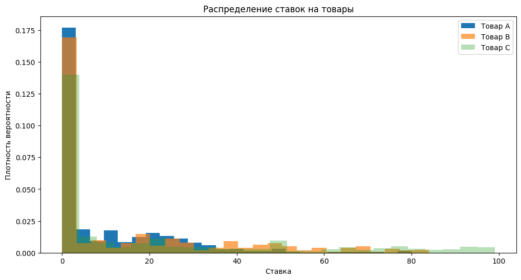

```python
plot_goods_prices_distribution(with_zero=True)
```

Как видно из графика, самая популярная ставка - 0, поэтому для удобства исключим ее из рассмотрения.

### 1.2 Распределение ставок на товары за все игры без нулей

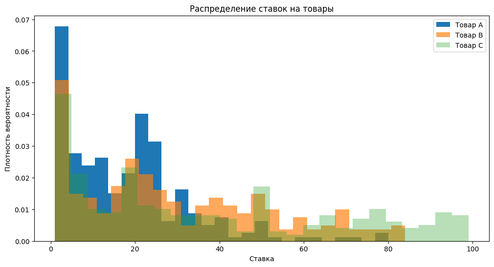

```python
plot_goods_prices_distribution(with_zero=False)
```

## 2. Распределение цен на товары

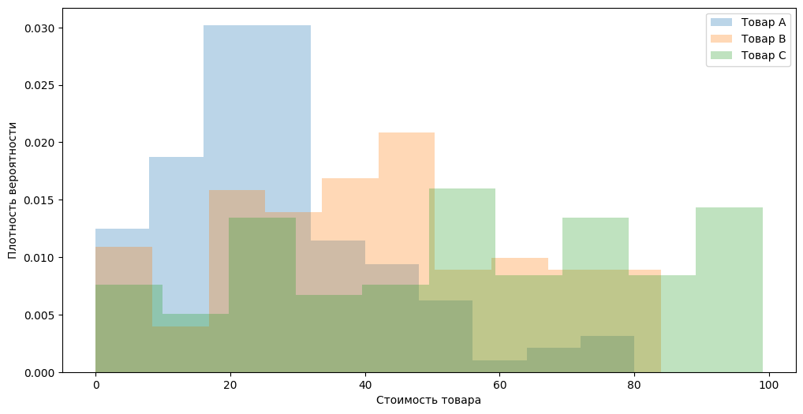

```python
plot_all_prices()
```

Аналогично, итоговые цены на товар А меньше чем на товар В. При этом цены на товар С в среднем выше, чем на товар В. При этом также цены на товар С распределены примерно равномерно на всем отрезке

## 3. Зависимость ожидаемой ставки от начального количества денег

### 3.1. Зависимость ожидаемой ставки от начального количества денег за все игры

Разобьем игроков по начальному количеству денег на несколько интервалов N и для каждого интервала найдем среднее значение ставки на товар. Для отображения будем использовать график вместо гистограммы для наглядности.

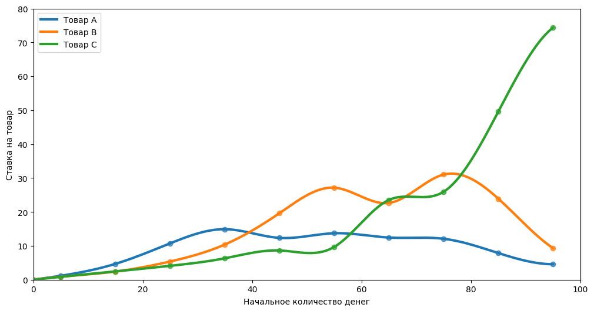

```python
plot_dist_for_all_goods()
```

Из данного графика видно, что чем больше денег у игрока, тем больше он ставит на более желанные товары.

### 3.2. Зависимость отношения ожидаемой ставки к начальному количеству денег в зависимости от начального количества денег за все игры

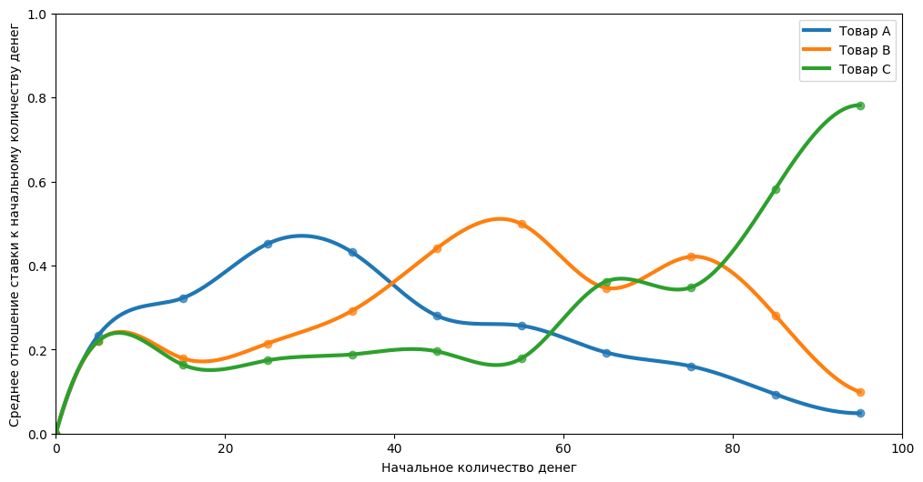

```python
plot_dist_for_all_goods_percentage()
```

На данном графике можно выделить 3 области: от 0 до 40, где основную часть денег ставят на товар А; от 40 до 80 - на товар В; от 80 до 100 главная ставка на товар С.

### 3.3. Ожидаемые ставки на товар А, B и С

Раунд 1 - информация о количестве денег других участников отсутствует

Раунд 2 - полная информация

Раунд 3 - не полная информация

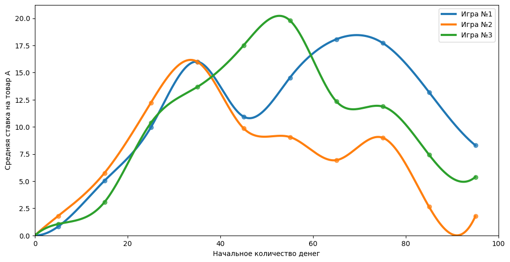

```python
plot_dist_for_good_in_sessions(good='a')
```

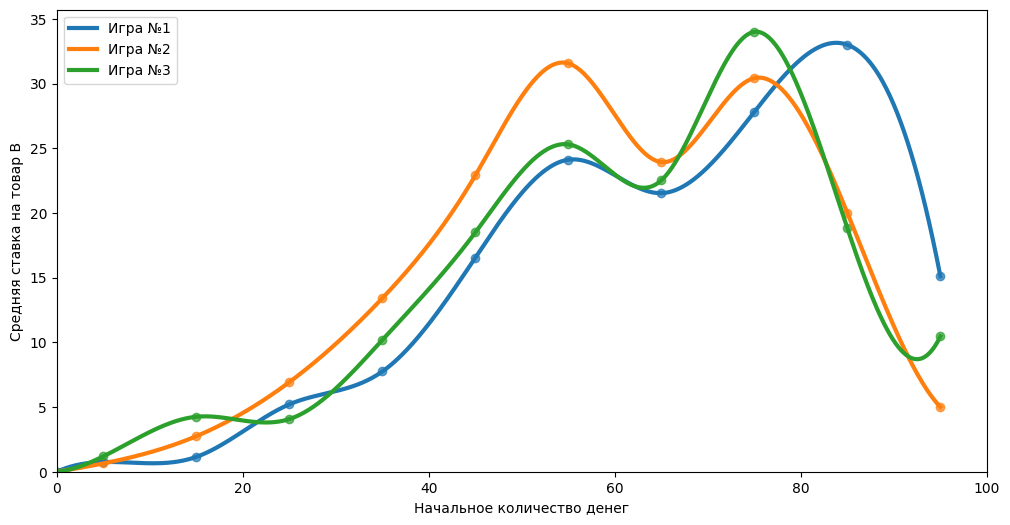

```python
plot_dist_for_good_in_sessions(good='b')
```

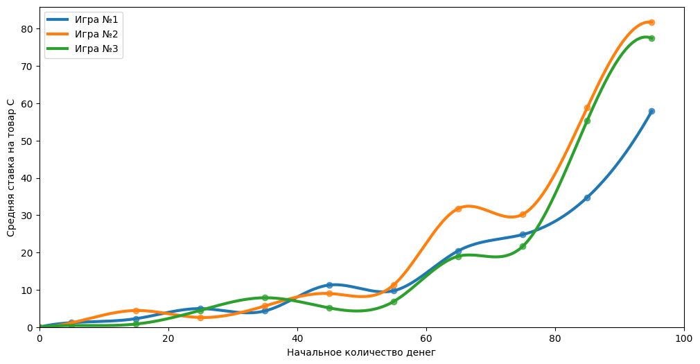

```python
plot_dist_for_good_in_sessions(good='c')
```

### 3.4. Средние ставки на каждый товар по играм

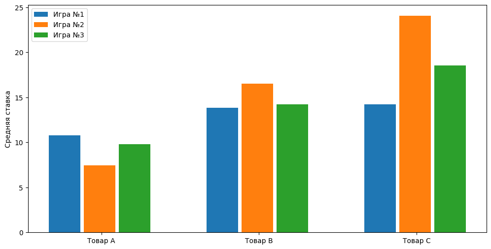

```python
plot_all_mean_bids()
```

**Вывод:** во 2-й игре с наибольшей осведомленностью ставки на товары сильнее всего отличаются. Скорее всего это связано с тем, что игроки могли предугадать, на какой товар они могут претендовать. Напротив, в 1-й игре ставки на товары слабо отличаются.

Для всех товаров средняя ставка в 3-й игре находится между ставками в 1-й и 2-й играх. Это значит, что в условиях частичной осведомленности, игроки выбирали некую промежуточную стратегию между ожидаемыми стратегиями в 1 и 2 игре.

## 4. Анализ ставок

Проверим, как начальное количество денег влияет на стратегию игроков в разных играх. Для этого разобьем игроков на 3 группы по количеству денег: от 0 до 25, от 25 до 75, от 75 до 100. Далее, построим для каждого интервала свою метрику:

1. Для первого интервала: $\frac{\text{money_left} + \text{bid_a}}{\text{available_money}}$
2. Для второго интервала: $\frac{\text{bid_b}}{\text{available_money}}$
3. Для третьего интервала: $\frac{\text{bid_c}}{\text{available_money}}$

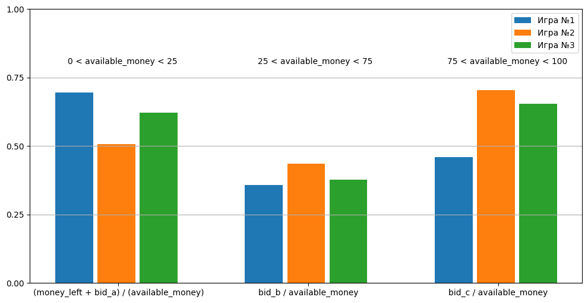

```python
plot_bids_analysis()
```

При этом из графика видно, что игроки проявляют риск-отрицательное поведение, так как в условиях отсутствия осведомленности их ставки смещены на товар А.

# 5. Выигрыши игроков

Разобьем игроков на 5 интервалов по начальному количеству денег и построим график среднего выигрыша игроков.

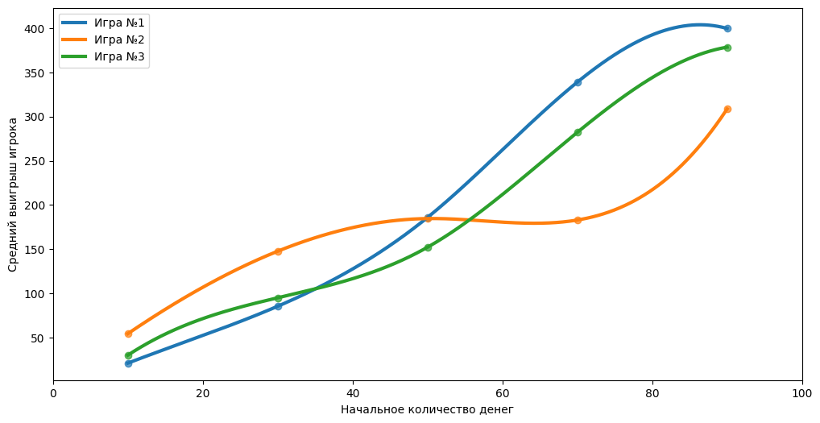

```python
plot_payoff_dist()
```

Из графика видно, что чем больше денег в начале, тем больше выигрыш. Сильнее всего эта зависимость проявляется в первой игре и слабее всего во второй. Как и в предыдущих результатах, третья игра расположена по середине.